# Fits and evaluates best model configs for lag study across main models in outer loop of nested for 1week window and 168 lead and v1

Author

John Curtin & Kendra Wyant

Published

July 4, 2024

### Code Status

In use for EMA study

### Notes

This script reads in CHTC performance metrics from the inner loops of CV, selects the best model configuration for each outer loop, trains those models and predicts into the outer held-out folds. Returns metrics, predictions (probabilities) and SHAPs

This script creates the following files in the `models` folder

- outer_metrics_*.rds
- outer_preds_*.rds
- outer_shaps_*.rds
- outer_shapsgrp_*.rds

where * = window_lead_version_cv

### To Do

SHAPS

- We get SHAPS in this script with 30 outer folds (3x10fold). It will be SHAPS from different models BUT they are currently all XGBoost and regardless, SHAP could work with any algorithm. We could ALSO average across same person for 3 repeats or just have 3x sample size SHAPs for each feature. We choose to **average across repeats**.
- Could get SHAPS when we did simple 3x10-fold on full sample to figure out the ONE best configuration. First run on CHTC to get best config. Then use that best config to predict into 30 held out folds and combine.
- Could train that ONE best config on full sample and use it for SHAPS in the full sample.

### Set Up Environment

```r
study <- params$study
data_type <- params$data_type
window <- params$window
lead <- params$lead
version <- params$version
cv <- params$cv
model <- params$model
```

Function conflicts

```r
# handle conflicts
options(conflicts.policy = "depends.ok")
devtools::source_url("https://github.com/jjcurtin/lab_support/blob/main/fun_ml.R?raw=true")
tidymodels_conflictRules()
```

Packages for script

```r
library(tidyverse)
library(tidymodels)
library(probably)
```

Source support functions

```r
# EDA
devtools::source_url("https://github.com/jjcurtin/lab_support/blob/main/fun_eda.R?raw=true")
```

```
ℹ SHA-1 hash of file is "c045eee2655a18dc85e715b78182f176327358a7"
```

```r
devtools::source_url("https://github.com/jjcurtin/lab_support/blob/main/format_path.R?raw=true")
```

```
ℹ SHA-1 hash of file is "a58e57da996d1b70bb9a5b58241325d6fd78890f"
```

```r
# CHTC support functions
devtools::source_url("https://github.com/jjcurtin/lab_support/blob/main/chtc/static_files/fun_chtc.R?raw=true")
```

```
ℹ SHA-1 hash of file is "75cc6f7b855da59c240908bd936834b4da01285b"
```

Absolute paths

```r
path_processed <- format_path(str_c("studydata/risk/data_processed/", study))
path_input <- format_path(str_c("studydata/risk/chtc/", study))
path_models <- format_path(str_c("studydata/risk/models/", study))
```

Chunk Defaults

### Script Functions

Function to clean up poor choices for feature names for SHAPs!!

```r
clean_feature_names <- function(feat_name){
  new_name <- gsub(".l0", "", feat_name)
  new_name <- gsub("rratecount.count", "raw_count", new_name)
  new_name <- gsub("dratecount.count", "diff_count", new_name)
  new_name <- gsub("drecent_response", "diff_recent", new_name)
  new_name <- gsub("rrecent_response", "raw_recent", new_name)
  new_name <- gsub("dmin_response", "diff_min", new_name)
  new_name <- gsub("rmin_response", "raw_min", new_name)
  new_name <- gsub("dmax_response", "diff_max", new_name)
  new_name <- gsub("rmax_response", "raw_max", new_name)
  new_name <- gsub("dmedian_response", "diff_median", new_name)
  new_name <- gsub("rmedian_response", "raw_median", new_name)
  new_name <- gsub("label_", "", new_name)
  new_name <- gsub("demo_", "", new_name)
  new_name <- gsub("High.school.or.less", "high.school", new_name)
  new_name <- gsub("Some.college", "some.college", new_name)
  new_name <- gsub("Mon", "mon", new_name)
  new_name <- gsub("Tue", "tue", new_name)
  new_name <- gsub("Wed", "wed", new_name)
  new_name <- gsub("Thu", "thu", new_name)
  new_name <- gsub("Fri", "fri", new_name)
  new_name <- gsub("Sat", "sat", new_name)
  new_name <- gsub("Sun", "sun", new_name)
  new_name <- gsub("Never.Married", "never.married", new_name)
  new_name <- gsub("Never.Other", "never.other", new_name)
  new_name <- gsub("White.Caucasian", "caucasian", new_name)
  new_name <- gsub("Male", "male", new_name)
  new_name <- gsub("p12.raw_count.lapse", "lapse.p12.raw_count", new_name)
  new_name <- gsub("p24.raw_count.lapse", "lapse.p24.raw_count", new_name)
  new_name <- gsub("p48.raw_count.lapse", "lapse.p48.raw_count", new_name)
  new_name <- gsub("p72.raw_count.lapse", "lapse.p72.raw_count", new_name)
  new_name <- gsub("p168.raw_count.lapse", "lapse.p168.raw_count", new_name)
  new_name <- gsub("p12.diff_count.lapse", "lapse.p12.diff_count", new_name)
  new_name <- gsub("p24.diff_count.lapse", "lapse.p24.diff_count", new_name)
  new_name <- gsub("p48.diff_count.lapse", "lapse.p48.diff_count", new_name)
  new_name <- gsub("p72.diff_count.lapse", "lapse.p72.diff_count", new_name)
  new_name <- gsub("p168.diff_count.lapse", "lapse.p168.diff_count", new_name)
  new_name <- gsub("p12.raw_count.ema", "missing.p12.raw_count", new_name)
  new_name <- gsub("p24.raw_count.ema", "missing.p24.raw_count", new_name)
  new_name <- gsub("p48.raw_count.ema", "missing.p48.raw_count", new_name)
  new_name <- gsub("p72.raw_count.ema", "missing.p72.raw_count", new_name)
  new_name <- gsub("p168.raw_count.ema", "missing.p168.raw_count", new_name)
  new_name <- gsub("p12.diff_count.ema", "missing.p12.diff_count", new_name)
  new_name <- gsub("p24.diff_count.ema", "missing.p24.diff_count", new_name)
  new_name <- gsub("p48.diff_count.ema", "missing.p48.diff_count", new_name)
  new_name <- gsub("p72.diff_count.ema", "missing.p72.diff_count", new_name)
  new_name <- gsub("p168.diff_count.ema", "missing.p168.diff_count", new_name)
  return(new_name)
}
```

Function to fit, predict, and calc metrics, preds, shaps

```r
fit_predict_eval <- function(split_num, splits, configs_best){

  # write tmp file to repo to track progress through loop
  # delete this file when script is complete.
  write_csv(tibble(stage = "eval",
                   outer_split_num = split_num,
                   start_time = Sys.time()),
            here::here(path_models, str_c("tmp_metrics_outer_progress_", window)),
            append = TRUE)

  d_in <- training(splits$splits[[split_num]]) |>
    select(-id_obs)  # not used for training; only needed in d_out to tag for later joins
  d_out <- testing(splits$splits[[split_num]])

  config_best <- configs_best |>
    slice(split_num) |>
    rename(n_jobs_in = n_jobs, accuracy_in = accuracy,
           bal_accuracy_in = bal_accuracy,
           roc_auc_in = roc_auc, sens_in =  sens, spec_in = spec,
           ppv_in = ppv, npv_in = npv)

  rec <- build_recipe(d = d_in, config = config_best)
  rec_prepped <- rec |>
    prep(training = d_in, strings_as_factors = FALSE)

  feat_in <- rec_prepped |>
    bake(new_data = NULL)

  model_best <- fit_best_model(config_best, feat = feat_in, "classification")

  feat_out <- rec_prepped |>
    bake(new_data = d_out)   # no id_obs because not included in d_in

  # metrics from raw (uncalibrated) predictions for held out fold
  preds_prob <- predict(model_best, feat_out,
                        type = "prob")
  preds_class <- predict(model_best, feat_out, type = "class")$.pred_class

  roc <- tibble(truth = feat_out$y,
                prob = preds_prob[[str_c(".pred_", y_level_pos)]]) %>%
      roc_auc(prob, truth = truth, event_level = "first") %>%
      select(metric = .metric,
             estimate = .estimate)

  cm <- tibble(truth = feat_out$y, estimate = preds_class) %>%
    conf_mat(truth, estimate)

  metrics_out <- cm |>
    summary(event_level = "first") |>
    select(metric = .metric,
           estimate = .estimate) |>
    filter(metric %in% c("sens", "spec", "ppv", "npv", "accuracy", "bal_accuracy")) |>
    suppressWarnings() |>  # warning not about metrics we are returning
    bind_rows(roc) |>
    pivot_wider(names_from = "metric", values_from = "estimate") |>
    relocate(roc_auc, sens, spec, ppv, npv, accuracy, bal_accuracy) |>
    bind_cols(config_best) |>
    relocate(outer_split_num, algorithm, feature_set, hp1, hp2, hp3,
             resample) |>
    relocate(accuracy_in, bal_accuracy_in, .after = last_col())

  if (model != "baseline") {
    # train calibration model train/test split on held in data
    # Skip for baseline models
    set.seed(2468)
    cal_split <- d_in |>
      group_initial_split(group = all_of(cv_group), prop = 3/4)
    d_cal_in <- training(cal_split)
    d_cal_out <- testing(cal_split)

    feat_cal_in <- rec %>%
      prep(training = d_cal_in, strings_as_factors = FALSE) %>%
      bake(new_data = NULL)

    feat_cal_out <- rec %>%
      prep(training = d_cal_in, strings_as_factors = FALSE) %>%
      bake(new_data = d_cal_out)

    model_cal <- fit_best_model(config_best, feat = feat_cal_in, "classification")

    # iso calibration
    iso <- predict(model_cal, feat_cal_out,
                   type = "prob") |>
      mutate(truth = feat_cal_out$y) |>
      cal_estimate_isotonic(truth = truth,
                            estimate = dplyr::starts_with(".pred_"))
    preds_prob_iso <- preds_prob |>
      cal_apply(iso)

    # logistic calibration
    logi <- predict(model_cal, feat_cal_out,
                   type = "prob") |>
      mutate(truth = feat_cal_out$y) |>
      cal_estimate_logistic(truth = truth,
                             estimate = dplyr::starts_with(".pred_"),
                             smooth = TRUE)
    preds_prob_logi <- preds_prob |>
      cal_apply(logi)

    # beta calibration
    beta <- predict(model_cal, feat_cal_out,
                   type = "prob") |>
      mutate(truth = feat_cal_out$y) |>
      cal_estimate_beta(truth = truth,
                             estimate = dplyr::starts_with(".pred_"),
                             smooth = TRUE)
    preds_prob_beta <- preds_prob |>
      cal_apply(beta)

    # combine raw and calibrated probs
    probs_out <- tibble(id_obs = d_out$id_obs,
                        outer_split_num = rep(split_num, nrow(preds_prob)),
                        prob_raw = preds_prob[[str_c(".pred_", y_level_pos)]],
                        prob_iso = preds_prob_iso[[str_c(".pred_", y_level_pos)]],
                        prob_logi = preds_prob_logi[[str_c(".pred_", y_level_pos)]],
                        prob_beta = preds_prob_beta[[str_c(".pred_", y_level_pos)]],
                        label = d_out$y) |>
      mutate(label = fct_recode(label, "No lapse" = "no",
                                "Lapse" = "yes"))

    # SHAP in held out fold
    # shaps_out <- SHAPforxgboost::shap.prep(xgb_model = extract_fit_engine(model_best),
    #                    X_train = feat_out |> select(-y) |>  as.matrix()) |>
    #  # add id_obs by multiple of number of features
    #   mutate(id_obs = rep(d_out$id_obs, times = ncol(feat_out) - 1),
    #          split_num = split_num) |>
    #   relocate(id_obs, split_num)

    return(list(probs_out = probs_out,
                metrics_out = metrics_out))
                # shaps_out = shaps_out))
  } else {
    probs_out <- tibble(id_obs = d_out$id_obs,
                        outer_split_num = rep(split_num, nrow(preds_prob)),
                        prob_raw = preds_prob[[str_c(".pred_", y_level_pos)]],
                        label = d_out$y) |>
    mutate(label = fct_recode(label, "No lapse" = "no",
                                "Lapse" = "yes"))
    return(list(probs_out = probs_out,
                metrics_out = metrics_out))
  }
}
```

### Read in aggregate CHTC metrics for inner folds

```r
metrics_raw <-
  read_csv(here::here(path_models, str_c("inner_metrics_", window,
                                   "_", lead, "_", version, "_", cv, "_", model, ".csv")),
           col_types = "iiiiccdddcdddddddi") |>
  glimpse()
```

```
Rows: 168,000
Columns: 17
$ config_num      <int> 49951, 49952, 49953, 49954, 49955, 49956, 49957, 49958…
$ split_num       <int> NA, NA, NA, NA, NA, NA, NA, NA, NA, NA, NA, NA, NA, NA…
$ outer_split_num <int> 9, 9, 9, 9, 9, 9, 9, 9, 9, 9, 9, 9, 9, 9, 9, 9, 9, 9, …
$ inner_split_num <int> 10, 10, 10, 10, 10, 10, 10, 10, 10, 10, 10, 10, 10, 10…
$ algorithm       <chr> "xgboost", "xgboost", "xgboost", "xgboost", "xgboost",…
$ feature_set     <chr> "all", "all", "all", "all", "all", "all", "all", "all"…
$ hp1             <dbl> 0.001, 0.001, 0.001, 0.001, 0.001, 0.001, 0.001, 0.001…
$ hp2             <dbl> 2, 2, 2, 2, 2, 2, 2, 2, 2, 2, 3, 3, 3, 3, 3, 3, 3, 3, …
$ hp3             <dbl> 40, 40, 40, 40, 40, 50, 50, 50, 50, 50, 20, 20, 20, 20…
$ resample        <chr> "none", "up_1", "up_2", "down_1", "down_2", "none", "u…
$ sens            <dbl> 0.5055351, 0.8870146, 0.6362678, 0.8870146, 0.6362678,…
$ spec            <dbl> 0.9370852, 0.8520042, 0.9009822, 0.8506769, 0.9030396,…
$ ppv             <dbl> 0.7521569, 0.6935971, 0.7081948, 0.6916964, 0.7125148,…
$ npv             <dbl> 0.8338254, 0.9523032, 0.8676978, 0.9522324, 0.8679594,…
$ accuracy        <dbl> 0.8187774, 0.8616022, 0.8284118, 0.8606388, 0.8299051,…
$ bal_accuracy    <dbl> 0.7213101, 0.8695094, 0.7686250, 0.8688458, 0.7696537,…
$ roc_auc         <dbl> 0.8927686, 0.8938141, 0.8926372, 0.8945320, 0.8918136,…
```

### Identify best config for each outer fold (i.e., across inner folds)

Average metrics for each configuration across inner folds for each outer fold (XGBOOST only)

```r
metrics_avg <- metrics_raw |>
  filter(algorithm == "xgboost") |>
  group_by(algorithm, feature_set, hp1, hp2, hp3, resample, outer_split_num) |>
   summarize(across(c(accuracy, bal_accuracy, roc_auc, sens, spec, ppv, npv),
                     median),
              n_jobs = n(), .groups = "drop") |>
  relocate(outer_split_num, n_jobs) |>
  arrange(outer_split_num, desc(roc_auc))
```

Best configuration for each outer fold

```r
configs_best <- metrics_avg |>
  group_by(outer_split_num) |>
  arrange(desc(roc_auc)) |>
  slice(1) |>
  ungroup() |>
  relocate(roc_auc, .before = accuracy)

configs_best |> print_kbl()
```

| outer_split_num | n_jobs | algorithm | feature_set | hp1 | hp2 | hp3 | resample | roc_auc | accuracy | bal_accuracy | sens | spec | ppv | npv |
| --- | --- | --- | --- | --- | --- | --- | --- | --- | --- | --- | --- | --- | --- | --- |
| 1 | 10 | xgboost | all | 0.01 | 1 | 40 | down_1 | 0.86 | 0.85 | 0.79 | 0.77 | 0.84 | 0.60 | 0.92 |
| 2 | 10 | xgboost | all | 0.00 | 3 | 50 | none | 0.88 | 0.84 | 0.75 | 0.59 | 0.92 | 0.71 | 0.86 |
| 3 | 10 | xgboost | all | 0.00 | 2 | 30 | none | 0.88 | 0.84 | 0.74 | 0.55 | 0.94 | 0.76 | 0.88 |
| 4 | 10 | xgboost | all | 0.10 | 1 | 20 | down_1 | 0.88 | 0.82 | 0.80 | 0.72 | 0.84 | 0.57 | 0.92 |
| 5 | 10 | xgboost | all | 0.10 | 1 | 50 | up_1 | 0.90 | 0.82 | 0.80 | 0.75 | 0.83 | 0.65 | 0.91 |
| 6 | 10 | xgboost | all | 0.00 | 4 | 20 | up_1 | 0.87 | 0.82 | 0.80 | 0.84 | 0.82 | 0.58 | 0.94 |
| 7 | 10 | xgboost | all | 0.01 | 1 | 20 | up_2 | 0.87 | 0.83 | 0.75 | 0.64 | 0.89 | 0.70 | 0.89 |
| 8 | 10 | xgboost | all | 0.00 | 4 | 50 | none | 0.89 | 0.82 | 0.76 | 0.64 | 0.90 | 0.71 | 0.88 |
| 9 | 10 | xgboost | all | 0.01 | 2 | 20 | none | 0.90 | 0.82 | 0.74 | 0.59 | 0.93 | 0.69 | 0.85 |
| 10 | 10 | xgboost | all | 0.10 | 1 | 50 | up_2 | 0.88 | 0.83 | 0.78 | 0.65 | 0.89 | 0.70 | 0.88 |
| 11 | 10 | xgboost | all | 0.01 | 3 | 30 | down_2 | 0.89 | 0.84 | 0.77 | 0.62 | 0.88 | 0.64 | 0.89 |
| 12 | 10 | xgboost | all | 0.01 | 2 | 50 | up_2 | 0.85 | 0.83 | 0.72 | 0.60 | 0.90 | 0.58 | 0.89 |
| 13 | 10 | xgboost | all | 0.00 | 3 | 50 | up_1 | 0.88 | 0.83 | 0.81 | 0.81 | 0.84 | 0.58 | 0.94 |
| 14 | 10 | xgboost | all | 0.00 | 4 | 30 | none | 0.87 | 0.81 | 0.76 | 0.62 | 0.90 | 0.71 | 0.86 |
| 15 | 10 | xgboost | all | 0.01 | 2 | 50 | none | 0.88 | 0.84 | 0.75 | 0.62 | 0.91 | 0.72 | 0.87 |
| 16 | 10 | xgboost | all | 0.01 | 2 | 20 | down_2 | 0.88 | 0.82 | 0.76 | 0.61 | 0.88 | 0.66 | 0.89 |
| 17 | 10 | xgboost | all | 0.01 | 2 | 50 | down_2 | 0.88 | 0.84 | 0.79 | 0.69 | 0.90 | 0.71 | 0.89 |
| 18 | 10 | xgboost | all | 0.10 | 1 | 30 | down_1 | 0.89 | 0.82 | 0.82 | 0.78 | 0.83 | 0.58 | 0.91 |
| 19 | 10 | xgboost | all | 0.01 | 3 | 40 | down_2 | 0.90 | 0.85 | 0.78 | 0.68 | 0.90 | 0.66 | 0.89 |
| 20 | 10 | xgboost | all | 0.00 | 2 | 20 | up_1 | 0.89 | 0.83 | 0.83 | 0.81 | 0.85 | 0.64 | 0.93 |
| 21 | 10 | xgboost | all | 0.01 | 2 | 20 | down_2 | 0.86 | 0.83 | 0.75 | 0.69 | 0.90 | 0.63 | 0.89 |
| 22 | 10 | xgboost | all | 0.00 | 2 | 40 | up_2 | 0.87 | 0.84 | 0.76 | 0.65 | 0.86 | 0.62 | 0.90 |
| 23 | 10 | xgboost | all | 0.01 | 3 | 20 | up_2 | 0.87 | 0.84 | 0.79 | 0.69 | 0.87 | 0.64 | 0.90 |
| 24 | 10 | xgboost | all | 0.00 | 4 | 50 | up_2 | 0.90 | 0.84 | 0.80 | 0.76 | 0.85 | 0.65 | 0.92 |
| 25 | 10 | xgboost | all | 0.01 | 2 | 20 | none | 0.87 | 0.84 | 0.72 | 0.54 | 0.92 | 0.70 | 0.88 |
| 26 | 10 | xgboost | all | 0.01 | 2 | 50 | up_2 | 0.88 | 0.84 | 0.78 | 0.66 | 0.89 | 0.67 | 0.87 |
| 27 | 10 | xgboost | all | 0.01 | 2 | 50 | down_2 | 0.86 | 0.81 | 0.77 | 0.69 | 0.85 | 0.63 | 0.90 |
| 28 | 10 | xgboost | all | 0.01 | 4 | 50 | up_1 | 0.88 | 0.82 | 0.80 | 0.77 | 0.82 | 0.57 | 0.92 |
| 29 | 10 | xgboost | all | 0.01 | 1 | 20 | none | 0.87 | 0.81 | 0.72 | 0.50 | 0.94 | 0.71 | 0.83 |
| 30 | 10 | xgboost | all | 0.01 | 2 | 40 | down_1 | 0.91 | 0.86 | 0.85 | 0.83 | 0.87 | 0.65 | 0.93 |

```r
configs_best |> pull(roc_auc) |> mean()
```

```
[1] 0.8798402
```

```r
configs_best |> pull(roc_auc) |> median()
```

```
[1] 0.8809736
```

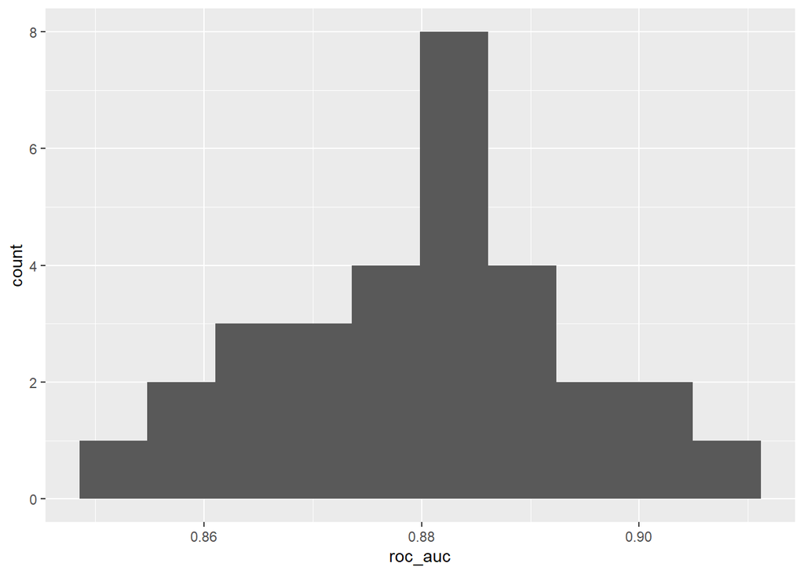

```r
configs_best |>
  ggplot(aes(x = roc_auc)) +
  geom_histogram(bins = 10)
```

### Fit best model for each outer fold and get/save metrics, preds, SHAPs

Get data from ANY batch (all same) and make splits

ASSUMPTIONS:

- Data are same for all batches
- format_data() is same for all batches
- Assumes full recipe is for all algorithms is present in all training controls with branches/ifs to select proper algorithm specific steps

Map over all outer splits to get predicted probabilities, metrics, and SHAPs from held out outer folds. Then save predicted probs, metrics, and SHAPs

NOTE: Delete `outer_metrics_*` or this code chunk won’t run!

```r
if(!file.exists(here::here(path_models, str_c("outer_metrics_",
                                  window, "_", lead, "_", version, "_",
                                  cv, "_", model, ".rds")))){

  # can source any training control given assumptions above
  batch_names <- list.dirs(path_input, full.names = FALSE, recursive = FALSE)
  batch_names <- batch_names[str_detect(batch_names, "train") &
                               str_detect(batch_names, cv) &
                               str_detect(batch_names, version) &
                               str_detect(batch_names, window) &
                               str_detect(batch_names,
                                          str_c(as.character(lead), "lag"))]
    if (model == "main") {
      batch_names <- batch_names[!str_detect(batch_names, "baseline")]
    }

  batch_name <- batch_names[1] # can source any batch given assumptions above
  path_batch <- here::here(path_input, batch_name)
  source(here::here(path_batch, "input", "training_controls.R"))
  # NOTE: training controls overwrites path_batch but it matches

  chunks <- str_split_fixed(data_trn, "\\.", n = Inf) # parse name from extensions
  if (length(chunks) == 2) {
    fn <- str_c("data_trn.", chunks[[2]])
  } else {
    fn <- str_c("data_trn.", chunks[[2]], ".", chunks[[3]])
  }

  # open based on file type
  if (str_detect(fn, "csv")) {
    d <- read_csv(here::here(path_batch, "input", fn), show_col_types = FALSE)
  } else {
    d <- read_rds(here::here(path_batch, "input", fn))
  }

  d <- format_data(d) |>
    arrange(label_num) |>
    mutate(id_obs = 1:nrow(d))  # tmp add for linking obs

  splits <- d %>%
    make_splits(cv_resample_type, cv_resample, cv_outer_resample,
                cv_inner_resample, cv_group, seed_splits)

  all <- configs_best$outer_split_num |>
    map(\(split_num) fit_predict_eval(split_num, splits, configs_best))


  rm(splits)  # save a bit of memory!

  write_csv(tibble(stage = "metrics_save",
                   outer_split_num = NA,
                   start_time = Sys.time()),
            here::here(path_models, str_c("tmp_metrics_outer_progress_", window)),
            append = TRUE)
  metrics_out <- all |>
    map(\(l) pluck(l, "metrics_out")) |>
    list_rbind() |>
    write_rds(here::here(path_models, str_c("outer_metrics_",
                                           window, "_", lead, "_", version, "_",
                                           cv, "_", model, ".rds")))
  write_csv(tibble(stage = "probs_save",
                   outer_split_num = NA,
                   start_time = Sys.time()),
            here::here(path_models, str_c("tmp_metrics_outer_progress_",window)),
            append = TRUE)
  probs_out <- all |>
    map(\(l) pluck(l, "probs_out")) |>
    list_rbind() |>
    write_rds(here::here(path_models, str_c("outer_preds_",
                                           window, "_", lead, "_", version, "_",
                                           cv, "_", model, ".rds")))

    write_csv(tibble(stage = "shaps_save",
                   outer_split_num = NA,
                   start_time = Sys.time()),
            here::here(path_models, str_c("tmp_metrics_outer_progress_", window)),
            append = TRUE)
  if (model != "baseline") {
    # Don't save out shapley values for baseline model
    # shaps_out <- all |>
    #   map(\(l) pluck(l, "shaps_out")) |>
    #   list_rbind() |>
    #   # clean feature names;  See function above
    #   mutate(variable = fct_relabel(variable, clean_feature_names)) |>
    #   # average SHAP metrics across repeats for same id_obs
    #   group_by(id_obs, variable) |>
    #   summarize(value = mean(value),
    #             # rfvalue is same across repeats but want included
    #             rfvalue =  mean(rfvalue),
    #             mean_value = mean(mean_value)) |>
    #   write_rds(here::here(path_models, str_c("outer_shaps_",
    #                                          window, "_", lead, "_", version, "_",
    #                                          cv, "_", model, ".rds")))
    }

} else {
  message("Resampled performance from nested CV previously calculated")

  metrics_out <- read_rds(here::here(path_models, str_c("outer_metrics_",
                                                       window, "_", lead, "_",
                                                       version, "_",
                                                       cv, "_", model, ".rds")))
  # not needed for remainder of script
  # probs_out <- read_rds(here::here(path_models, str_c("outer_preds_",
  #                                                    window, "_", lead, "_",
  #                                                    version, "_",
  #                                                    cv, "_", model, ".rds")))

  if (model != "baseline") {
    shaps_out <- read_rds(here::here(path_models, str_c("outer_shaps_",
                                                     window, "_", lead, "_",
                                                     version, "_",
                                                     cv, "_", model, ".rds")))
  }
}
```

```
Resampled performance from nested CV previously calculated
```

````r
# shaps_v1 <- tibble()
# split_num <- 1
#
# while (split_num <= 10) {
#   d_in <-
#     training(splits$splits[[split_num]]) |>
#     select(-id_obs)  # not used for training; only needed in d_out to tag for later joins
#   d_out <- testing(splits$splits[[split_num]])
#
#   config_best <- configs_best |>
#     slice(split_num) |>
#     rename(n_jobs_in = n_jobs, accuracy_in = accuracy,
#            bal_accuracy_in = bal_accuracy,
#            roc_auc_in = roc_auc, sens_in =  sens, spec_in = spec,
#            ppv_in = ppv, npv_in = npv)
#
#   rec <- build_recipe(d = d_in, config = config_best)
#   rec_prepped <- rec |>
#     prep(training = d_in, strings_as_factors = FALSE)
#
#   feat_in <- rec_prepped |>
#     bake(new_data = NULL)
#
#   model_best <- fit_best_model(config_best, feat = feat_in, "classification")
#
#   feat_out <- rec_prepped |>
#     bake(new_data = d_out)   # no id_obs because not included in d_in
#
#
#     shaps_out <- SHAPforxgboost::shap.prep(xgb_model = extract_fit_engine(model_best),
#                        X_train = feat_out |> select(-y) |>  as.matrix()) |>
#      # add id_obs by multiple of number of features
#       mutate(id_obs = rep(d_out$id_obs, times = ncol(feat_out) - 1),
#              split_num = split_num) |>
#       relocate(id_obs, split_num)
#
#      shaps_v1 <- shaps_v1 |> bind_rows(shaps_out)
#
#      split_num <- split_num + 1
# }
#
# shaps_v1 |>
#   mutate(variable = fct_relabel(variable, clean_feature_names)) |>
#   # average SHAP metrics across repeats for same id_obs
#   group_by(id_obs, variable) |>
#   summarize(value = mean(value),
#             # rfvalue is same across repeats but want included
#             rfvalue =  mean(rfvalue),
#             mean_value = mean(mean_value)) |>
#   write_rds(here::here(path_models, str_c("outer_shaps_",
#                                          window, "_", lead, "_", version, "_",
#                                          cv, "_", model, "_batch5.rds")))
# ```
#
# ```{r}
# shaps_batch1 <- read_rds(here::here(path_models, str_c("outer_shaps_",
#                                                   window, "_", lead, "_",
#                                                   version, "_",
#                                                   cv, "_", model, "_batch1.rds")))
#
# shaps_batch2 <- read_rds(here::here(path_models, str_c("outer_shaps_",
#                                                   window, "_", lead, "_",
#                                                   version, "_",
#                                                   cv, "_", model, "_batch2.rds")))
# shaps_batch3 <- read_rds(here::here(path_models, str_c("outer_shaps_",
#                                                   window, "_", lead, "_",
#                                                   version, "_",
#                                                   cv, "_", model, "_batch3.rds")))
# shaps_batch4 <- read_rds(here::here(path_models, str_c("outer_shaps_",
#                                                   window, "_", lead, "_",
#                                                   version, "_",
#                                                   cv, "_", model, "_batch4.rds")))
# shaps_batch5 <- read_rds(here::here(path_models, str_c("outer_shaps_",
#                                                   window, "_", lead, "_",
#                                                   version, "_",
#                                                   cv, "_", model, "_batch5.rds")))
#
# shaps_out <- shaps_batch1 |>
#   bind_rows(shaps_batch2) |>
#   bind_rows(shaps_batch3) |>
#   bind_rows(shaps_batch4) |>
#   bind_rows(shaps_batch5) |>
#   group_by(id_obs, variable) |>
#    summarize(value = mean(value),
#             # rfvalue is same across repeats but want included
#             rfvalue =  mean(rfvalue),
#             mean_value = mean(mean_value))
#
# rm(shaps_batch1)
# rm(shaps_batch2)
#
# shaps_out_2 <- shaps_batch3 |>
#   bind_rows(shaps_batch4) |>
#   bind_rows(shaps_batch5) |>
#   group_by(id_obs, variable) |>
#    summarize(value = mean(value),
#             # rfvalue is same across repeats but want included
#             rfvalue =  mean(rfvalue),
#             mean_value = mean(mean_value))
#
# rm(shaps_batch3)
# rm(shaps_batch4)
# rm(shaps_batch5)
#
# shaps_out <- shaps_out |>
#   bind_rows(shaps_out_2) |>
#   group_by(id_obs, variable) |>
#    summarize(value = mean(value),
#             # rfvalue is same across repeats but want included
#             rfvalue =  mean(rfvalue),
#             mean_value = mean(mean_value))
#
#
# shaps_out |> write_rds(here::here(path_models, str_c("outer_shaps_",
#                                          window, "_", lead, "_", version, "_",
#                                          cv, "_", model, ".rds")))
#
#  shaps_out_grp <- shaps_out %>%
#     mutate(variable_grp = if_else(str_detect(variable, ".lapse"),
#                            "past use (EMA item)",
#                            variable),
#            variable_grp = if_else(str_detect(variable_grp, "ema_2"),
#                            "craving (EMA item)",
#                            variable_grp),
#            variable_grp = if_else(str_detect(variable_grp, "ema_3"),
#                            "past risky situation (EMA item)",
#                            variable_grp),
#            variable_grp = if_else(str_detect(variable_grp, "ema_4"),
#                            "past stressful event (EMA item)",
#                            variable_grp),
#            variable_grp = if_else(str_detect(variable_grp, "ema_5"),
#                            "past pleasant event (EMA item)",
#                            variable_grp),
#            variable_grp = if_else(str_detect(variable_grp, "ema_6"),
#                            "valence (EMA item)",
#                            variable_grp),
#            variable_grp = if_else(str_detect(variable_grp, "ema_7"),
#                            "arousal (EMA item)",
#                            variable_grp),
#            variable_grp = if_else(str_detect(variable_grp, "ema_8"),
#                            "future risky situation (EMA item)",
#                            variable_grp),
#            variable_grp = if_else(str_detect(variable_grp, "ema_9"),
#                            "future stressful event (EMA item)",
#                            variable_grp),
#            variable_grp = if_else(str_detect(variable_grp, "ema_10"),
#                            "future efficacy (EMA item)",
#                            variable_grp),
#            variable_grp = if_else(str_detect(variable_grp, ".ema$"),
#                            "missing surveys (other)",
#                            variable_grp),
#            variable_grp = if_else(str_detect(variable_grp, "day"),
#                            "lapse day (other)",
#                            variable_grp),
#            variable_grp = if_else(str_detect(variable_grp, "hour"),
#                            "lapse hour (other)",
#                            variable_grp),
#            variable_grp = if_else(str_detect(variable_grp, "age"),
#                            "age (demographic)",
#                            variable_grp),
#            variable_grp = if_else(str_detect(variable_grp, "sex"),
#                            "sex (demographic)",
#                            variable_grp),
#            variable_grp = if_else(str_detect(variable_grp, "marital"),
#                            "marital (demographic)",
#                            variable_grp),
#            variable_grp = if_else(str_detect(variable_grp, "race"),
#                            "race (demographic)",
#                            variable_grp),
#            variable_grp = if_else(str_detect(variable_grp, "educ"),
#                            "education (demographic)",
#                            variable_grp),
#            variable_grp = if_else(str_detect(variable_grp, "income"),
#                            "income (demographic)",
#                            variable_grp),
#            variable_grp = if_else(str_detect(variable_grp, "employ"),
#                            "employment (demographic)",
#                            variable_grp)) %>%
#     mutate(variable_grp = factor(variable_grp)) %>%
#     group_by(id_obs, variable_grp) %>% # values are already averaged across repeats
#     summarize(value = sum(value))
#
#   shaps_out_grp %>% write_rds(here::here(path_models,
#                                           str_c("outer_shapsgrp_", window, "_",
#                                                 lead, "_", version, "_",
#                                                 cv, "_", model, ".rds")))
````

Now group SHAPs

- NOTE: Delete `outer_shapsgrp_*` or this code chunk won’t run!
- NOTE: not run for baseline models

```r
if(!file.exists(here::here(path_models, str_c("outer_shapsgrp_",
                                            window, "_", lead, "_", version, "_",
                                            cv, "_", model, ".rds"))) & model != "baseline"){

  message("Calculating grouped SHAPs")
  write_csv(tibble(stage = "shapsgrp_save",
                   outer_split_num = NA,
                   start_time = Sys.time()),
            here::here(path_models, str_c("tmp_metrics_outer_progress_",window)),
            append = TRUE)

  shaps_out_grp <- shaps_out %>%
    mutate(variable_grp = if_else(str_detect(variable, "lapse."),
                           "past use (EMA item)",
                           variable),
           variable_grp = if_else(str_detect(variable_grp, "ema_2"),
                           "craving (EMA item)",
                           variable_grp),
           variable_grp = if_else(str_detect(variable_grp, "ema_3"),
                           "past risky situation (EMA item)",
                           variable_grp),
           variable_grp = if_else(str_detect(variable_grp, "ema_4"),
                           "past stressful event (EMA item)",
                           variable_grp),
           variable_grp = if_else(str_detect(variable_grp, "ema_5"),
                           "past pleasant event (EMA item)",
                           variable_grp),
           variable_grp = if_else(str_detect(variable_grp, "ema_6"),
                           "valence (EMA item)",
                           variable_grp),
           variable_grp = if_else(str_detect(variable_grp, "ema_7"),
                           "arousal (EMA item)",
                           variable_grp),
           variable_grp = if_else(str_detect(variable_grp, "ema_8"),
                           "future risky situation (EMA item)",
                           variable_grp),
           variable_grp = if_else(str_detect(variable_grp, "ema_9"),
                           "future stressful event (EMA item)",
                           variable_grp),
           variable_grp = if_else(str_detect(variable_grp, "ema_10"),
                           "future efficacy (EMA item)",
                           variable_grp),
           variable_grp = if_else(str_detect(variable_grp, "missing."),
                           "missing surveys (other)",
                           variable_grp),
           variable_grp = if_else(str_detect(variable_grp, "day"),
                           "lapse day (other)",
                           variable_grp),
           variable_grp = if_else(str_detect(variable_grp, "hour"),
                           "lapse hour (other)",
                           variable_grp),
           variable_grp = if_else(str_detect(variable_grp, "age"),
                           "age (demographic)",
                           variable_grp),
           variable_grp = if_else(str_detect(variable_grp, "sex"),
                           "sex (demographic)",
                           variable_grp),
           variable_grp = if_else(str_detect(variable_grp, "marital"),
                           "marital (demographic)",
                           variable_grp),
           variable_grp = if_else(str_detect(variable_grp, "race"),
                           "race (demographic)",
                           variable_grp),
           variable_grp = if_else(str_detect(variable_grp, "educ"),
                           "education (demographic)",
                           variable_grp),
           variable_grp = if_else(str_detect(variable_grp, "income"),
                           "income (demographic)",
                           variable_grp),
           variable_grp = if_else(str_detect(variable_grp, "employ"),
                           "employment (demographic)",
                           variable_grp)) %>%
    mutate(variable_grp = factor(variable_grp)) %>%
    group_by(id_obs, variable_grp) %>% # values are already averaged across repeats
    summarize(value = sum(value))

  # shaps_out_grp %>% write_rds(here::here(path_models,
  #                                         str_c("outer_shapsgrp_", window, "_",
  #                                               lead, "_", version, "_",
  #                                               cv, "_", model, ".rds")))
} else {
   message("Grouped SHAPs previously calculated")
}
```

```
Grouped SHAPs previously calculated
```

### Final Review performance eval from outer loop

Done more in depth later script but here is a quick look

```r
metrics_out |>
  print_kbl()
```

| outer_split_num | algorithm | feature_set | hp1 | hp2 | hp3 | resample | roc_auc | sens | spec | ppv | npv | accuracy | bal_accuracy | n_jobs_in | roc_auc_in | sens_in | spec_in | ppv_in | npv_in | accuracy_in | bal_accuracy_in |
| --- | --- | --- | --- | --- | --- | --- | --- | --- | --- | --- | --- | --- | --- | --- | --- | --- | --- | --- | --- | --- | --- |
| 1 | xgboost | all | 0.01 | 1 | 40 | down_1 | 0.85 | 0.85 | 0.69 | 0.64 | 0.88 | 0.75 | 0.77 | 10 | 0.86 | 0.77 | 0.84 | 0.60 | 0.92 | 0.85 | 0.79 |
| 2 | xgboost | all | 0.00 | 3 | 50 | none | 0.89 | 0.66 | 0.91 | 0.74 | 0.88 | 0.85 | 0.79 | 10 | 0.88 | 0.59 | 0.92 | 0.71 | 0.86 | 0.84 | 0.75 |
| 3 | xgboost | all | 0.00 | 2 | 30 | none | 0.82 | 0.32 | 0.98 | 0.67 | 0.90 | 0.89 | 0.65 | 10 | 0.88 | 0.55 | 0.94 | 0.76 | 0.88 | 0.84 | 0.74 |
| 4 | xgboost | all | 0.10 | 1 | 20 | down_1 | 0.92 | 0.73 | 0.93 | 0.82 | 0.89 | 0.87 | 0.83 | 10 | 0.88 | 0.72 | 0.84 | 0.57 | 0.92 | 0.82 | 0.80 |
| 5 | xgboost | all | 0.10 | 1 | 50 | up_1 | 0.84 | 0.81 | 0.72 | 0.66 | 0.85 | 0.76 | 0.77 | 10 | 0.90 | 0.75 | 0.83 | 0.65 | 0.91 | 0.82 | 0.80 |
| 6 | xgboost | all | 0.00 | 4 | 20 | up_1 | 0.91 | 0.90 | 0.83 | 0.72 | 0.95 | 0.86 | 0.87 | 10 | 0.87 | 0.84 | 0.82 | 0.58 | 0.94 | 0.82 | 0.80 |
| 7 | xgboost | all | 0.01 | 1 | 20 | up_2 | 0.85 | 0.43 | 0.95 | 0.56 | 0.91 | 0.88 | 0.69 | 10 | 0.87 | 0.64 | 0.89 | 0.70 | 0.89 | 0.83 | 0.75 |
| 8 | xgboost | all | 0.00 | 4 | 50 | none | 0.82 | 0.26 | 0.92 | 0.26 | 0.92 | 0.85 | 0.59 | 10 | 0.89 | 0.64 | 0.90 | 0.71 | 0.88 | 0.82 | 0.76 |
| 9 | xgboost | all | 0.01 | 2 | 20 | none | 0.87 | 0.56 | 0.96 | 0.86 | 0.84 | 0.84 | 0.76 | 10 | 0.90 | 0.59 | 0.93 | 0.69 | 0.85 | 0.82 | 0.74 |
| 10 | xgboost | all | 0.10 | 1 | 50 | up_2 | 0.76 | 0.57 | 0.77 | 0.32 | 0.90 | 0.74 | 0.67 | 10 | 0.88 | 0.65 | 0.89 | 0.70 | 0.88 | 0.83 | 0.78 |
| 11 | xgboost | all | 0.01 | 3 | 30 | down_2 | 0.82 | 0.35 | 0.94 | 0.62 | 0.83 | 0.81 | 0.64 | 10 | 0.89 | 0.62 | 0.88 | 0.64 | 0.89 | 0.84 | 0.77 |
| 12 | xgboost | all | 0.01 | 2 | 50 | up_2 | 0.85 | 0.58 | 0.87 | 0.55 | 0.88 | 0.81 | 0.73 | 10 | 0.85 | 0.60 | 0.90 | 0.58 | 0.89 | 0.83 | 0.72 |
| 13 | xgboost | all | 0.00 | 3 | 50 | up_1 | 0.90 | 0.88 | 0.80 | 0.78 | 0.89 | 0.83 | 0.84 | 10 | 0.88 | 0.81 | 0.84 | 0.58 | 0.94 | 0.83 | 0.81 |
| 14 | xgboost | all | 0.00 | 4 | 30 | none | 0.89 | 0.71 | 0.86 | 0.67 | 0.88 | 0.82 | 0.79 | 10 | 0.87 | 0.62 | 0.90 | 0.71 | 0.86 | 0.81 | 0.76 |
| 15 | xgboost | all | 0.01 | 2 | 50 | none | 0.90 | 0.59 | 0.92 | 0.77 | 0.84 | 0.82 | 0.76 | 10 | 0.88 | 0.62 | 0.91 | 0.72 | 0.87 | 0.84 | 0.75 |
| 16 | xgboost | all | 0.01 | 2 | 20 | down_2 | 0.95 | 0.81 | 0.95 | 0.71 | 0.97 | 0.93 | 0.88 | 10 | 0.88 | 0.61 | 0.88 | 0.66 | 0.89 | 0.82 | 0.76 |
| 17 | xgboost | all | 0.01 | 2 | 50 | down_2 | 0.85 | 0.59 | 0.89 | 0.64 | 0.86 | 0.81 | 0.74 | 10 | 0.88 | 0.69 | 0.90 | 0.71 | 0.89 | 0.84 | 0.79 |
| 18 | xgboost | all | 0.10 | 1 | 30 | down_1 | 0.85 | 0.84 | 0.77 | 0.54 | 0.94 | 0.79 | 0.81 | 10 | 0.89 | 0.78 | 0.83 | 0.58 | 0.91 | 0.82 | 0.82 |
| 19 | xgboost | all | 0.01 | 3 | 40 | down_2 | 0.83 | 0.73 | 0.82 | 0.50 | 0.93 | 0.80 | 0.78 | 10 | 0.90 | 0.68 | 0.90 | 0.66 | 0.89 | 0.85 | 0.78 |
| 20 | xgboost | all | 0.00 | 2 | 20 | up_1 | 0.87 | 0.84 | 0.89 | 0.66 | 0.95 | 0.88 | 0.86 | 10 | 0.89 | 0.81 | 0.85 | 0.64 | 0.93 | 0.83 | 0.83 |
| 21 | xgboost | all | 0.01 | 2 | 20 | down_2 | 0.88 | 0.60 | 0.97 | 0.73 | 0.94 | 0.92 | 0.78 | 10 | 0.86 | 0.69 | 0.90 | 0.63 | 0.89 | 0.83 | 0.75 |
| 22 | xgboost | all | 0.00 | 2 | 40 | up_2 | 0.81 | 0.65 | 0.79 | 0.60 | 0.82 | 0.74 | 0.72 | 10 | 0.87 | 0.65 | 0.86 | 0.62 | 0.90 | 0.84 | 0.76 |
| 23 | xgboost | all | 0.01 | 3 | 20 | up_2 | 0.84 | 0.64 | 0.85 | 0.71 | 0.81 | 0.78 | 0.75 | 10 | 0.87 | 0.69 | 0.87 | 0.64 | 0.90 | 0.84 | 0.79 |
| 24 | xgboost | all | 0.00 | 4 | 50 | up_2 | 0.88 | 0.76 | 0.80 | 0.57 | 0.90 | 0.79 | 0.78 | 10 | 0.90 | 0.76 | 0.85 | 0.65 | 0.92 | 0.84 | 0.80 |
| 25 | xgboost | all | 0.01 | 2 | 20 | none | 0.89 | 0.68 | 0.89 | 0.80 | 0.81 | 0.81 | 0.79 | 10 | 0.87 | 0.54 | 0.92 | 0.70 | 0.88 | 0.84 | 0.72 |
| 26 | xgboost | all | 0.01 | 2 | 50 | up_2 | 0.81 | 0.56 | 0.81 | 0.34 | 0.91 | 0.77 | 0.69 | 10 | 0.88 | 0.66 | 0.89 | 0.67 | 0.87 | 0.84 | 0.78 |
| 27 | xgboost | all | 0.01 | 2 | 50 | down_2 | 0.91 | 0.70 | 0.95 | 0.81 | 0.92 | 0.90 | 0.83 | 10 | 0.86 | 0.69 | 0.85 | 0.63 | 0.90 | 0.81 | 0.77 |
| 28 | xgboost | all | 0.01 | 4 | 50 | up_1 | 0.76 | 0.55 | 0.85 | 0.37 | 0.92 | 0.81 | 0.70 | 10 | 0.88 | 0.77 | 0.82 | 0.57 | 0.92 | 0.82 | 0.80 |
| 29 | xgboost | all | 0.01 | 1 | 20 | none | 0.90 | 0.58 | 0.95 | 0.76 | 0.90 | 0.87 | 0.77 | 10 | 0.87 | 0.50 | 0.94 | 0.71 | 0.83 | 0.81 | 0.72 |
| 30 | xgboost | all | 0.01 | 2 | 40 | down_1 | 0.95 | 0.90 | 0.92 | 0.85 | 0.95 | 0.92 | 0.91 | 10 | 0.91 | 0.83 | 0.87 | 0.65 | 0.93 | 0.86 | 0.85 |

```r
metrics_out |>
  summarize(median(roc_auc), mean(roc_auc), min(roc_auc), max(roc_auc))
```

```
# A tibble: 1 × 4
  `median(roc_auc)` `mean(roc_auc)` `min(roc_auc)` `max(roc_auc)`
              <dbl>           <dbl>          <dbl>          <dbl>
1             0.860           0.863          0.760          0.949
```

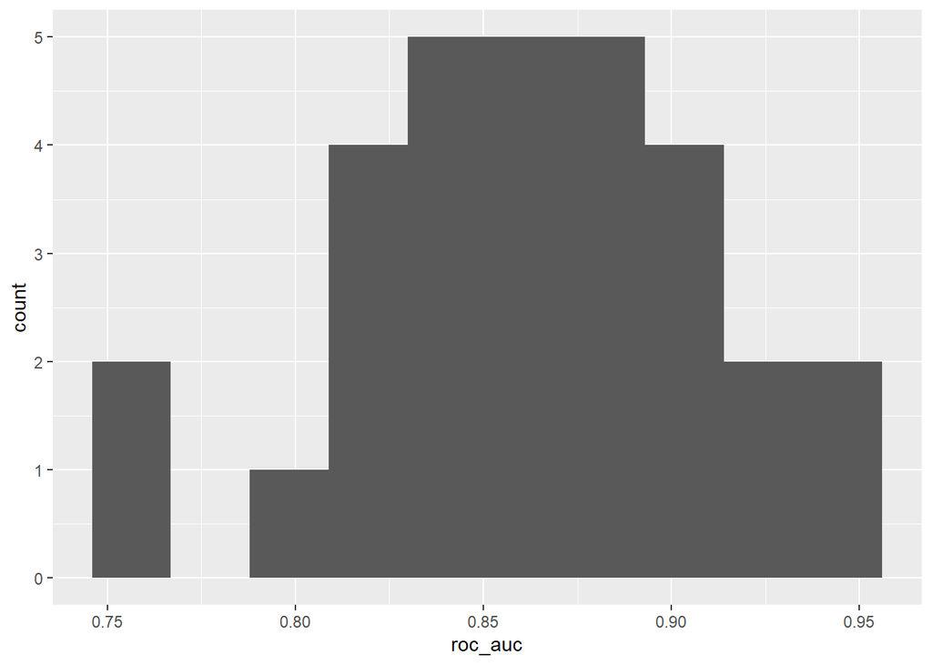

```r
metrics_out |>
  ggplot(aes(x = roc_auc)) +
  geom_histogram(bins = 10)
```

```r
# delete tracking file
# if(file.exists(here::here(path_models, str_c("tmp_metrics_outer_progress_", window)))) {
#   file.remove(here::here(path_models, str_c("tmp_metrics_outer_progress_", window)))
# }
```

IMPORTANT: We still need to select ONE final best config using the inner resampling approach AND then we need to fit that best config to ALL the data.